# Zaufanie społeczne i gotowość do kooperacji — analiza danych World Values Survey

Projekt zaliczeniowy z przedmiotu Metody Probabilistyczne

Mykyta Tolstykh (nr indeksu: 44094)

Danyil Fiut (nr indeksu: 48991)

24.05.2026

# 1 CZĘŚĆ I — Metryczka i opis danych

## 1.1 1.1. Skład grupy i podział prac

Tabela 1. Podział prac w grupie

| Członek grupy | Nr indeksu | Zakres odpowiedzialności |
| --- | --- | --- |
| Mykyta Tolstykh | 44094 | Przygotowanie danych (Część I), statystyki opisowe (Część II), analiza korelacji (Część V.1), montaż raportu |
| Danyil Fiut | 48991 | Analiza prawdopodobieństw (Część III), testowanie hipotez (Część IV), regresja liniowa (Część V.2), wnioski końcowe |

## 1.2 1.2. Cel badania

**Problem badawczy:** *Jakie czynniki demograficzne i kulturowe determinują skłonność jednostek do kooperatywnego zachowania w społeczeństwie?*

Badanie łączy perspektywę socjologiczną (zaufanie społeczne, kapitał społeczny) z aparatem teorii gier (klasyczny dylemat więźnia, problem „pasażera na gapę”). Pytania ankietowe World Values Survey o zaufanie do innych ludzi oraz o usprawiedliwianie zachowań typu free-rider traktujemy jako **behawioralne wskaźniki** gotowości do kooperacji w realnych dylematach społecznych.

## 1.3 1.3. Źródło danych

- **Nazwa:** World Values Survey, Wave 7 (2017–2022)
- **Wersja:** v6.0
- **Źródło:** https://www.worldvaluessurvey.org/WVSDocumentationWV7.jsp
- **Format pliku:** CSV (`WVS_Cross-National_Wave_7_csv_v6_0.csv`, ~182 MB)
- **Liczba obserwacji w surowym pliku:** ~97 220 respondentów z 66 krajów
- **Liczba zmiennych w surowym pliku:** 613

## 1.4 1.4. Wczytanie i wstępne czyszczenie danych

```r
sciezka <- "data/WVS_Cross-National_Wave_7_csv_v6_0.csv"
raw <- fread(sciezka)

cat("Wymiary surowego zbioru:", dim(raw)[1], "wierszy x", dim(raw)[2], "kolumn\n")
```

```
## Wymiary surowego zbioru: 97220 wierszy x 613 kolumn
```

```r
dt <- raw[, .(
  trust       = Q57,
  cheat_taxes = Q180,
  cheat_fare  = Q177,
  happiness   = Q46,
  life_sat    = Q49,
  income      = Q288,
  age         = Q262,
  sex         = Q260,
  education   = Q275,
  country     = B_COUNTRY,
  religion    = Q6,
  politics    = Q240
)]

# Wartości ujemne w WVS = brak odpowiedzi — zamieniamy na NA
dt[dt < 0] <- NA
dt <- na.omit(dt)

# Rekodowanie zmiennych jakościowych
dt[, trust := ifelse(trust == 1, 1L, 0L)]
dt[, sex   := factor(sex, levels = c(1, 2), labels = c("Mężczyzna", "Kobieta"))]
dt[, education := factor(education,
                         levels = 0:8,
                         labels = c("Brak", "Podstawowe niepełne", "Podstawowe",
                                    "Gimnazjalne", "Średnie zawodowe", "Średnie",
                                    "Pomaturalne", "Licencjackie", "Magisterskie+"))]

cat("Wymiary po czyszczeniu:", dim(dt)[1], "wierszy x", dim(dt)[2], "kolumn\n")
```

```
## Wymiary po czyszczeniu: 64913 wierszy x 12 kolumn
```

## 1.5 1.5. Opis zmiennych

Tabela 2. Wybrane zmienne — opis i typ

| Zmienna | Kod WVS | Opis | Typ |
| --- | --- | --- | --- |
| trust | Q57 | Zaufanie do większości ludzi (0 = nie ufa, 1 = ufa) | binarna |
| cheat_taxes | Q180 | Usprawiedliwianie uchylania się od podatków (1–10) | ilościowa |
| cheat_fare | Q177 | Usprawiedliwianie jazdy bez biletu (1–10) | ilościowa |
| happiness | Q46 | Poziom szczęścia (1 = bardzo szczęśliwy, 4 = wcale) | porządkowa |
| life_sat | Q49 | Zadowolenie z życia (1–10) | ilościowa |
| income | Q288 | Decyl dochodu (1 = najniższy, 10 = najwyższy) | porządkowa |
| age | Q262 | Wiek respondenta | ilościowa |
| sex | Q260 | Płeć (1 = M, 2 = K) | jakościowa |
| education | Q275 | Najwyższy ukończony poziom wykształcenia | jakościowa |
| country | B_COUNTRY | Kod kraju | jakościowa |
| religion | Q6 | Znaczenie religii (1 = bardzo ważna, 4 = nieważna) | porządkowa |
| politics | Q240 | Poglądy polityczne (1 = lewica, 10 = prawica) | ilościowa |

# 2 CZĘŚĆ II — Parametry i rozkłady (analiza jednowymiarowa)

**Cel:** Opisać kluczową zmienną ilościową (`life_sat`) za pomocą statystyk położenia i kształtu oraz dopasować do niej rozkład teoretyczny.

## 2.1 2.1. Statystyki opisowe

```r
stats <- dt[, .(
  Srednia            = round(mean(life_sat), 3),
  Mediana            = round(median(life_sat), 3),
  Odch_std           = round(sd(life_sat), 3),
  Wsp_zmiennosci     = round(sd(life_sat) / mean(life_sat), 3),
  Skosnosc           = round(skewness(life_sat), 3),
  Kurtoza            = round(kurtosis(life_sat), 3),
  Min                = min(life_sat),
  Max                = max(life_sat),
  N                  = .N
)]
kable(stats, caption = "Tabela 3. Statystyki opisowe zmiennej `life_sat`")
```

Tabela 3. Statystyki opisowe zmiennej `life_sat`

| Srednia | Mediana | Odch_std | Wsp_zmiennosci | Skosnosc | Kurtoza | Min | Max | N |
| --- | --- | --- | --- | --- | --- | --- | --- | --- |
| 7.114 | 7 | 2.167 | 0.305 | -0.729 | 3.233 | 1 | 10 | 64913 |

**Interpretacja statystyk:**

Zmienna `life_sat` mierzy zadowolenie z życia w skali 1–10. Na podstawie powyższych wyników:

- **Średnia vs mediana:** jeśli wartości są zbliżone, rozkład jest w przybliżeniu symetryczny; większa różnica wskazuje na asymetrię.
- **Skośność:** wartość ujemna oznacza ogon rozkładu w lewą stronę (więcej respondentów jest zadowolonych); wartość dodatnia — ogon w prawo.
- **Kurtoza:** wartość powyżej 3 świadczy o bardziej spiczastym rozkładzie niż normalny (leptokurtyczny); poniżej 3 — bardziej spłaszczonym (platykurtyczny).
- **Współczynnik zmienności:** informuje o względnym zróżnicowaniu odpowiedzi w stosunku do średniej.

## 2.2 2.2. Histogram z dopasowaną krzywą rozkładu normalnego

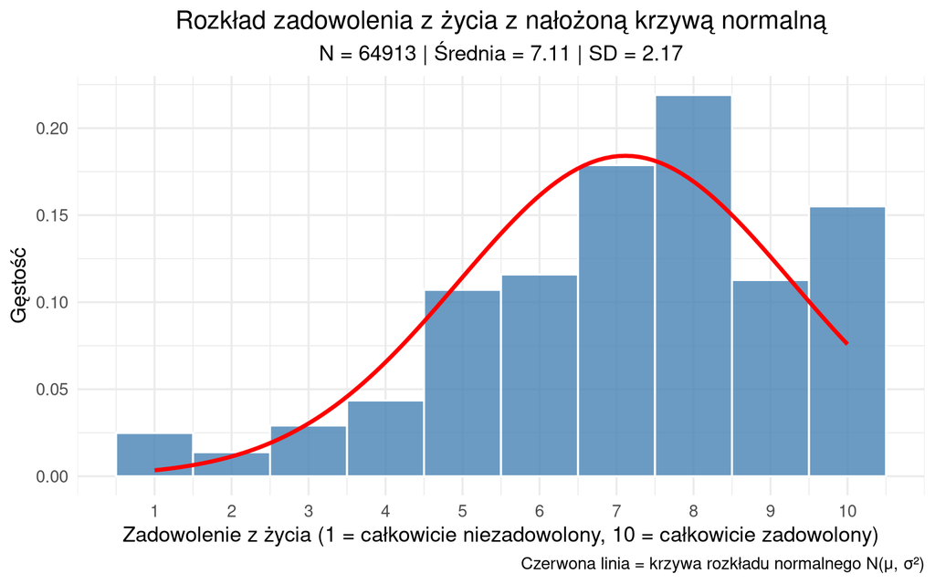

Rysunek 1. Rozkład zadowolenia z życia z nałożoną krzywą normalną

```r
m <- mean(dt$life_sat)
s <- sd(dt$life_sat)

ggplot(dt, aes(x = life_sat)) +
  geom_histogram(aes(y = after_stat(density)),
                 bins = 10, fill = "steelblue", color = "white", alpha = 0.8) +
  stat_function(fun = dnorm,
                args = list(mean = m, sd = s),
                color = "red", linewidth = 1.2) +
  scale_x_continuous(breaks = 1:10) +
  labs(
    title = "Rozkład zadowolenia z życia z nałożoną krzywą normalną",
    subtitle = paste0("N = ", nrow(dt),
                      " | Średnia = ", round(m, 2),
                      " | SD = ", round(s, 2)),
    x = "Zadowolenie z życia (1 = całkowicie niezadowolony, 10 = całkowicie zadowolony)",
    y = "Gęstość",
    caption = "Czerwona linia = krzywa rozkładu normalnego N(μ, σ²)"
  ) +
  theme_minimal(base_size = 13) +
  theme(plot.title = element_text(hjust = 0.5),
        plot.subtitle = element_text(hjust = 0.5))
```

## 2.3 2.3. Wniosek — dobór modelu rozkładu

```
## Średnia: 7.114 | Mediana: 7 | Różnica: 0.114
```

```
## Skośność: -0.729
```

```
## Kurtoza: 3.233 (dla rozkładu normalnego = 3)
```

**Ocena dopasowania:**

**Wniosek:** Biorąc pod uwagę dużą liczebność próby (N > 30 000), możemy oprzeć się na centralnym twierdzeniu granicznym i korzystać z testów parametrycznych. Rozkład wykazuje pewną asymetrię, jednak przy dużej próbie testy parametryczne są odporne na takie odchylenia.

# 3 CZĘŚĆ III — Prawdopodobieństwo i zmienne dwuwymiarowe

**Cel:** Zdefiniować dwa zdarzenia związane z gotowością do kooperacji, obliczyć ich prawdopodobieństwa bezwarunkowe i warunkowe oraz sprawdzić niezależność.

## 3.1 3.1. Definicje zdarzeń

W kontekście teorii gier rozpatrujemy dwa zdarzenia jako behawioralne wskaźniki postawy kooperatywnej:

- **Zdarzenie A** — *„Respondent ufa większości ludzi”* (`trust == 1`). Proxy dla skłonności do współpracy w klasycznym dylemacie więźnia — gracze ufający częściej wybierają strategię kooperatywną.
- **Zdarzenie B** — *„Respondent nigdy nie usprawiedliwia jazdy bez biletu”* (`cheat_fare == 1`). Proxy dla odrzucenia zachowania *free-rider* (pasażera na gapę) — kluczowego problemu w grach z dobrami publicznymi.

## 3.2 3.2. Obliczenie prawdopodobieństw

```r
PA  <- dt[, mean(trust == 1)]
PB  <- dt[, mean(cheat_fare == 1)]
PAB <- dt[, mean(trust == 1 & cheat_fare == 1)]
PA_given_B <- PAB / PB
PB_given_A <- PAB / PA
PA_PB <- PA * PB

prob_tab <- data.table(
  Wielkość = c("P(A)", "P(B)", "P(A∩B)", "P(A|B)", "P(B|A)", "P(A)·P(B)"),
  Wartość  = round(c(PA, PB, PAB, PA_given_B, PB_given_A, PA_PB), 4),
  Opis = c(
    "Częstość ufnych respondentów",
    "Częstość respondentów potępiających jazdę na gapę",
    "Częstość respondentów spełniających oba warunki",
    "Prawdopodobieństwo ufania pod warunkiem potępiania jazdy na gapę",
    "Prawdopodobieństwo potępiania jazdy na gapę pod warunkiem ufania",
    "Iloczyn — wartość oczekiwana przy hipotezie niezależności"
  )
)
kable(prob_tab, caption = "Tabela 4. Prawdopodobieństwa zdarzeń A i B")
```

Tabela 4. Prawdopodobieństwa zdarzeń A i B

| Wielkość | Wartość | Opis |
| --- | --- | --- |
| P(A) | 0.2453 | Częstość ufnych respondentów |
| P(B) | 0.4961 | Częstość respondentów potępiających jazdę na gapę |
| P(A∩B) | 0.1259 | Częstość respondentów spełniających oba warunki |
| P(A\|B) | 0.2539 | Prawdopodobieństwo ufania pod warunkiem potępiania jazdy na gapę |
| P(B\|A) | 0.5133 | Prawdopodobieństwo potępiania jazdy na gapę pod warunkiem ufania |
| P(A)·P(B) | 0.1217 | Iloczyn — wartość oczekiwana przy hipotezie niezależności |

## 3.3 3.3. Test niezależności

```r
tab_AB <- table(
  A = ifelse(dt$trust == 1, "ufa", "nie ufa"),
  B = ifelse(dt$cheat_fare == 1, "nigdy nie usprawiedliwia", "usprawiedliwia")
)
kable(tab_AB, caption = "Tabela 5. Tablica kontyngencji A × B (liczebności)")
```

Tabela 5. Tablica kontyngencji A × B (liczebności)

|  | nigdy nie usprawiedliwia | usprawiedliwia |
| --- | --- | --- |
| nie ufa | 24029 | 24959 |
| ufa | 8175 | 7750 |

```r
chi_test <- chisq.test(tab_AB)
chi_test
```

```
##
##  Pearson's Chi-squared test with Yates' continuity correction
##
## data:  tab_AB
## X-squared = 24.979, df = 1, p-value = 5.796e-07
```

## 3.4 3.4. Interpretacja

- **P(A∩B) = 0.1259** vs **P(A)·P(B) = 0.1217** — różnica wynosi **0.0042**, więc empiryczna częstość wspólnego wystąpienia jest większa niż przewiduje hipoteza niezależności.
- **P(A|B) = 0.2539** vs **P(A) = 0.2453** — prawdopodobieństwo zaufania *pod warunkiem* odrzucenia *free-riderstwa* jest o **3.5%** wyższe niż prawdopodobieństwo bezwarunkowe.
- **Test χ² niezależności:** statystyka = 24.98, df = 1, p-value = 5.8e-07.

**Wniosek statystyczny:** Ponieważ p-value < 0.05, odrzucamy hipotezę o niezależności zdarzeń A i B — są one statystycznie zależne.

**Interpretacja teorio-gracza:** Wynik wspiera koncepcję istnienia *kooperatywnego typu osobowości*. W modelach iterowanego dylematu więźnia (Axelrod, 1984) jednostki konsekwentnie wybierające strategie kooperatywne — zaufanie do innych oraz odrzucenie zachowań *free-rider* — tworzą rozpoznawalny klaster behawioralny. Nasze dane pokazują, że obie postawy współwystępują częściej, niż wynikałoby to z niezależności, co przemawia za tym, że gotowość do kooperacji jest cechą stosunkowo spójną, a nie zbiorem losowo niezależnych zachowań.

# 4 CZĘŚĆ IV — Wnioskowanie statystyczne (estymacja i hipotezy)

**Cel:** Zbudować 95% przedział ufności dla średniej oraz przeprowadzić pięć testów hipotez (3 dla zmiennych ilościowych + 2 dla jakościowych) wraz ze sprawdzeniem założeń i interpretacją.

## 4.1 4.1. Przedział ufności dla średniej `life_sat`

```r
ci <- t.test(dt$life_sat, conf.level = 0.95)
ci_tab <- data.table(
  `Średnia próbkowa`     = round(mean(dt$life_sat), 3),
  `Odch. std`            = round(sd(dt$life_sat), 3),
  `Dolna granica 95% CI` = round(ci$conf.int[1], 3),
  `Górna granica 95% CI` = round(ci$conf.int[2], 3),
  `Szerokość CI`         = round(ci$conf.int[2] - ci$conf.int[1], 3),
  N = nrow(dt)
)
kable(ci_tab, caption = "Tabela 6. 95% przedział ufności dla średniej zadowolenia z życia")
```

Tabela 6. 95% przedział ufności dla średniej zadowolenia z życia

| Średnia próbkowa | Odch. std | Dolna granica 95% CI | Górna granica 95% CI | Szerokość CI | N |
| --- | --- | --- | --- | --- | --- |
| 7.114 | 2.167 | 7.097 | 7.131 | 0.033 | 64913 |

**Interpretacja:** Z prawdopodobieństwem 95% prawdziwa średnia zadowolenia z życia w populacji leży w przedziale [7.097, 7.131]. Bardzo wąski przedział (0.033 jednostki skali) wynika z dużej liczebności próby (N = 64913).

## 4.2 4.2. Hipotezy dotyczące zmiennych ilościowych

### 4.2.1 H1 — Czy płeć różnicuje zadowolenie z życia?

**Hipotezy:**

- H₀: μ(life_sat | Mężczyzna) = μ(life_sat | Kobieta)
- H₁: średnie się różnią

**Sprawdzenie założeń:**

```r
# Statystyki opisowe w grupach
dt[, .(N = .N,
       srednia = round(mean(life_sat), 3),
       sd      = round(sd(life_sat), 3)), by = sex]
```

| sex | N | srednia | sd |
| --- | --- | --- | --- |
| Kobieta | 33340 | 7.130 | 2.167 |
| Mężczyzna | 31573 | 7.097 | 2.167 |

```r
# Test Levene'a — równość wariancji
levene_h1 <- car::leveneTest(life_sat ~ sex, data = dt)
levene_h1
```

|  | Df | F value | Pr(>F) |
| --- | --- | --- | --- |
| group | 1 | 1.320659 | 0.2504781 |
|  | 64911 | NA | NA |

Założenie normalności w grupach: test Shapiro-Wilka nie jest stosowany — jest niewiarygodny przy N > 5000 (odrzuca normalność dla dowolnych próbek tej wielkości). Przy N > 30 000 odwołujemy się do **centralnego twierdzenia granicznego** — rozkład średniej z próby jest w przybliżeniu normalny niezależnie od rozkładu cechy, a testy parametryczne są wówczas odporne na odchylenia od normalności. Dla bezpieczeństwa uruchamiamy równolegle nieparametryczny test Wilcoxona.

**Testy:**

```r
t_h1 <- t.test(life_sat ~ sex, data = dt)   # Welch (wariancje nierówne)
t_h1
```

```
##
##  Welch Two Sample t-test
##
## data:  life_sat by sex
## t = -1.9543, df = 64720, p-value = 0.05067
## alternative hypothesis: true difference in means between group Mężczyzna and group Kobieta is not equal to 0
## 95 percent confidence interval:
##  -6.660572e-02  9.765385e-05
## sample estimates:
## mean in group Mężczyzna   mean in group Kobieta
##                7.096950                7.130204
```

```r
w_h1 <- wilcox.test(life_sat ~ sex, data = dt)
w_h1
```

```
##
##  Wilcoxon rank sum test with continuity correction
##
## data:  life_sat by sex
## W = 521186827, p-value = 0.02936
## alternative hypothesis: true location shift is not equal to 0
```

### 4.2.2 H2 — Czy poziom wykształcenia różnicuje zadowolenie z życia?

**Hipotezy:**

- H₀: średnie `life_sat` są równe we wszystkich grupach wykształcenia
- H₁: co najmniej dwie grupy różnią się średnimi

```r
# Statystyki opisowe w grupach
dt[, .(N = .N, srednia = round(mean(life_sat), 3)),
   by = education][order(-srednia)]
```

| education | N | srednia |
| --- | --- | --- |
| Pomaturalne | 12131 | 7.303 |
| Licencjackie | 4505 | 7.300 |
| Magisterskie+ | 924 | 7.293 |
| Średnie | 5368 | 7.164 |
| Gimnazjalne | 16818 | 7.107 |
| Podstawowe | 9111 | 7.038 |
| Średnie zawodowe | 6138 | 7.016 |
| Podstawowe niepełne | 7253 | 6.992 |
| Brak | 2665 | 6.638 |

```r
# ANOVA (test parametryczny) + Kruskal-Wallis (nieparametryczny)
aov_h2 <- aov(life_sat ~ education, data = dt)
summary(aov_h2)
```

```
##                Df Sum Sq Mean Sq F value Pr(>F)
## education       8   1457  182.13   38.97 <2e-16 ***
## Residuals   64904 303347    4.67
## ---
## Signif. codes:  0 '***' 0.001 '**' 0.01 '*' 0.05 '.' 0.1 ' ' 1
```

```r
kw_h2 <- kruskal.test(life_sat ~ education, data = dt)
kw_h2
```

```
##
##  Kruskal-Wallis rank sum test
##
## data:  life_sat by education
## Kruskal-Wallis chi-squared = 170.39, df = 8, p-value < 2.2e-16
```

**Wynik:** ANOVA: F(8, 6.4904^{4}) = 38.97, p = <2e-16. Kruskal–Wallis: χ² = 170.39, df = 8, p = <2e-16.

**Wniosek:** Odrzucamy H₀ — poziom wykształcenia istotnie różnicuje średnie zadowolenia z życia. Tendencja widoczna w tabeli wskazuje, że wyższe wykształcenie wiąże się z wyższym zadowoleniem z życia.

### 4.2.3 H3 — Czy kraj różnicuje tolerancję wobec uchylania się od podatków?

**Hipotezy:**

- H₀: średnia `cheat_taxes` jest taka sama w pięciu największych krajach próby
- H₁: co najmniej dwa kraje różnią się średnimi

```r
# Wybór 5 największych krajów w próbie
top5 <- dt[, .N, by = country][order(-N)][1:5, country]
dt_h3 <- dt[country %in% top5]
dt_h3[, country_f := factor(country)]

# Statystyki w grupach
dt_h3[, .(N = .N, srednia = round(mean(cheat_taxes), 3)),
      by = country_f][order(-srednia)]
```

| country_f | N | srednia |
| --- | --- | --- |
| 360 | 2665 | 2.603 |
| 124 | 3997 | 2.578 |
| 344 | 1866 | 2.303 |
| 840 | 2459 | 2.103 |
| 792 | 2051 | 1.720 |

```r
aov_h3 <- aov(cheat_taxes ~ country_f, data = dt_h3)
summary(aov_h3)
```

```
##                Df Sum Sq Mean Sq F value Pr(>F)
## country_f       4   1332   333.1   71.83 <2e-16 ***
## Residuals   13033  60435     4.6
## ---
## Signif. codes:  0 '***' 0.001 '**' 0.01 '*' 0.05 '.' 0.1 ' ' 1
```

```r
kw_h3 <- kruskal.test(cheat_taxes ~ country_f, data = dt_h3)
kw_h3
```

```
##
##  Kruskal-Wallis rank sum test
##
## data:  cheat_taxes by country_f
## Kruskal-Wallis chi-squared = 388.37, df = 4, p-value < 2.2e-16
```

**Wynik:** ANOVA: F(4, 1.3033^{4}) = 71.83, p = <2e-16. Kruskal–Wallis: χ² = 388.37, df = 4, p = <2e-16.

**Wniosek:** Odrzucamy H₀ — istnieją istotne różnice międzykrajowe w tolerancji wobec uchylania się od podatków. Czynnik kulturowo-narodowy okazuje się jednym z silniejszych determinantów postaw wobec łamania norm fiskalnych.

## 4.3 4.3. Hipotezy dotyczące zmiennych jakościowych

### 4.3.1 H4 — Czy płeć i zaufanie są niezależne?

**Hipotezy:**

- H₀: zmienne `sex` i `trust` są niezależne
- H₁: istnieje zależność między płcią a poziomem zaufania

```r
tab_h4 <- table(`Płeć` = dt$sex,
                Zaufanie = ifelse(dt$trust == 1, "ufa", "nie ufa"))
kable(tab_h4, caption = "Tabela 7. Płeć × zaufanie (liczebności)")
```

Tabela 7. Płeć × zaufanie (liczebności)

|  | nie ufa | ufa |
| --- | --- | --- |
| Mężczyzna | 23575 | 7998 |
| Kobieta | 25413 | 7927 |

```r
chi_h4 <- chisq.test(tab_h4)
chi_h4
```

```
##
##  Pearson's Chi-squared test with Yates' continuity correction
##
## data:  tab_h4
## X-squared = 21.109, df = 1, p-value = 4.338e-06
```

**Wynik:** χ² = 21.109, df = 1, p = 4.34e-06.

**Wniosek:** Odrzucamy H₀ — płeć i zaufanie nie są niezależne. Jedna z płci istotnie częściej deklaruje zaufanie do innych ludzi.

### 4.3.2 H5 — Czy znaczenie religii i tolerancja wobec uchylania się od podatków są niezależne?

**Hipotezy:**

- H₀: zmienne `religion` i kategoria `cheat_taxes` są niezależne
- H₁: istnieje zależność między religijnością a tolerancją wobec uchylania się od podatków

```r
# Kategoryzacja zmiennej cheat_taxes (1–10) na 3 poziomy
dt[, cheat_taxes_cat := cut(cheat_taxes,
                            breaks         = c(0, 3, 7, 10),
                            labels         = c("niska", "średnia", "wysoka"),
                            include.lowest = TRUE)]
dt[, religion_cat := factor(religion, levels = 1:4,
                            labels = c("bardzo ważna", "raczej ważna",
                                       "raczej nieważna", "nieważna"))]

tab_h5 <- table(Religia    = dt$religion_cat,
                Tolerancja = dt$cheat_taxes_cat)
kable(tab_h5, caption = "Tabela 8. Znaczenie religii × tolerancja podatkowa (liczebności)")
```

Tabela 8. Znaczenie religii × tolerancja podatkowa (liczebności)

|  | niska | średnia | wysoka |
| --- | --- | --- | --- |
| bardzo ważna | 23845 | 3719 | 1537 |
| raczej ważna | 10832 | 2405 | 610 |
| raczej nieważna | 9874 | 2218 | 408 |
| nieważna | 7493 | 1636 | 336 |

```r
chi_h5 <- chisq.test(tab_h5)
chi_h5
```

```
##
##  Pearson's Chi-squared test
##
## data:  tab_h5
## X-squared = 354.59, df = 6, p-value < 2.2e-16
```

**Wynik:** χ² = 354.59, df = 6, p = <2e-16.

## 4.4 4.4. Zbiorcza tabela wyników testów

Tabela 9. Zbiorcze wyniki testów hipotez (α = 0.05)

| Hipoteza | Zmienne | Test podstawowy | Test nieparam. | p-value | Decyzja |
| --- | --- | --- | --- | --- | --- |
| H1 | life_sat ~ sex | t-Welcha | Wilcoxon | 0.0507 | Brak podstaw |
| H2 | life_sat ~ education | ANOVA | Kruskal-Wallis | <2e-16 | Odrzucamy H₀ |
| H3 | cheat_taxes ~ country (top 5) | ANOVA | Kruskal-Wallis | <2e-16 | Odrzucamy H₀ |
| H4 | sex × trust | χ² | — | 4.34e-06 | Odrzucamy H₀ |
| H5 | religion × cheat_taxes | χ² | — | <2e-16 | Odrzucamy H₀ |

# 5 CZĘŚĆ V — Relacje i przewidywanie (korelacja i regresja)

## 5.1 5.1. Macierz korelacji

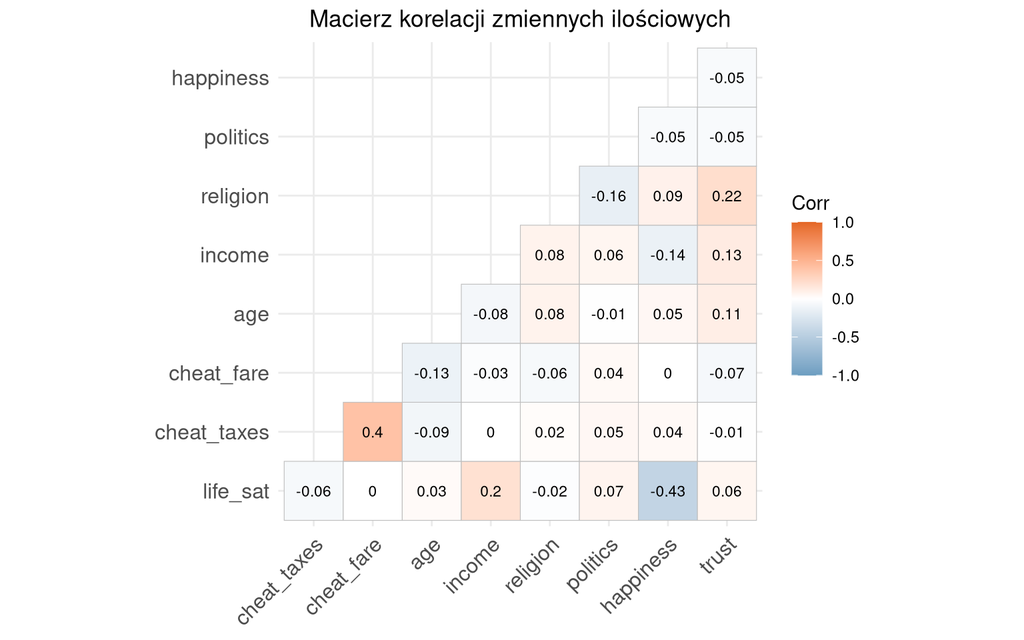

Rysunek 2. Macierz korelacji zmiennych ilościowych

```r
zmienne_num <- dt[, .(life_sat, cheat_taxes, cheat_fare, age,
                       income, religion, politics, happiness, trust)]
cor_mat <- cor(zmienne_num, use = "complete.obs")

ggcorrplot(cor_mat,
           lab = TRUE, lab_size = 3,
           type = "lower",
           colors = c("#6D9EC1", "white", "#E46726"),
           title = "Macierz korelacji zmiennych ilościowych") +
  theme(plot.title = element_text(hjust = 0.5))
```

```r
cat("=== Korelacja life_sat ~ happiness ===\n")
```

```
## === Korelacja life_sat ~ happiness ===
```

```r
print(cor.test(dt$life_sat, dt$happiness))
```

```
##
##  Pearson's product-moment correlation
##
## data:  dt$life_sat and dt$happiness
## t = -123.03, df = 64911, p-value < 2.2e-16
## alternative hypothesis: true correlation is not equal to 0
## 95 percent confidence interval:
##  -0.4410666 -0.4285902
## sample estimates:
##        cor
## -0.4348493
```

```r
cat("\n=== Korelacja life_sat ~ income ===\n")
```

```
##
## === Korelacja life_sat ~ income ===
```

```r
print(cor.test(dt$life_sat, dt$income))
```

```
##
##  Pearson's product-moment correlation
##
## data:  dt$life_sat and dt$income
## t = 52.164, df = 64911, p-value < 2.2e-16
## alternative hypothesis: true correlation is not equal to 0
## 95 percent confidence interval:
##  0.1931876 0.2079542
## sample estimates:
##       cor
## 0.2005823
```

**Interpretacja:** Najsilniejszą korelację z `life_sat` wykazuje `happiness` (r = -0.435, p < 2e-16) — znak ujemny wynika z odwróconej skali szczęścia (1 = bardzo szczęśliwy). Druga istotna korelacja to `income` (r = 0.201, p < 2e-16) — wyższy dochód wiąże się z wyższym zadowoleniem z życia. Obie korelacje są statystycznie istotne przy α = 0.05.

## 5.2 5.2. Regresja liniowa

**Cel:** Zbudować model liniowy przewidujący zadowolenie z życia (`life_sat`) na podstawie zmiennych demograficznych i kulturowych oraz ocenić, które z nich mają istotny wkład po wzajemnej kontroli.

### 5.2.1 5.2.1. Specyfikacja modelu

**Zmienna zależna:** `life_sat` (zadowolenie z życia, 1–10).

**Predyktory:** `age`, `sex`, `income`, `education`, `trust`, `religion`, `politics`.

```r
model <- lm(life_sat ~ age + sex + income + education + trust + religion + politics,
            data = dt)
model_summary <- summary(model)
model_summary
```

```
##
## Call:
## lm(formula = life_sat ~ age + sex + income + education + trust +
##     religion + politics, data = dt)
##
## Residuals:
##     Min      1Q  Median      3Q     Max
## -7.4844 -1.2722  0.2296  1.4576  4.5431
##
## Coefficients:
##                                Estimate Std. Error t value Pr(>|t|)
## (Intercept)                   5.1815539  0.0574388  90.210  < 2e-16 ***
## age                           0.0067763  0.0005118  13.239  < 2e-16 ***
## sexKobieta                    0.0677374  0.0166261   4.074 4.62e-05 ***
## income                        0.2032394  0.0041918  48.485  < 2e-16 ***
## educationPodstawowe niepełne  0.4003286  0.0478710   8.363  < 2e-16 ***
## educationPodstawowe           0.4449496  0.0468104   9.505  < 2e-16 ***
## educationGimnazjalne          0.4673858  0.0447058  10.455  < 2e-16 ***
## educationŚrednie zawodowe     0.3751609  0.0499235   7.515 5.78e-14 ***
## educationŚrednie              0.4599875  0.0508054   9.054  < 2e-16 ***
## educationPomaturalne          0.5292106  0.0466293  11.349  < 2e-16 ***
## educationLicencjackie         0.3900607  0.0532364   7.327 2.38e-13 ***
## educationMagisterskie+        0.3848326  0.0818552   4.701 2.59e-06 ***
## trust                         0.2059900  0.0201711  10.212  < 2e-16 ***
## religion                     -0.0902622  0.0080416 -11.224  < 2e-16 ***
## politics                      0.0493484  0.0034653  14.241  < 2e-16 ***
## ---
## Signif. codes:  0 '***' 0.001 '**' 0.01 '*' 0.05 '.' 0.1 ' ' 1
##
## Residual standard error: 2.111 on 64898 degrees of freedom
## Multiple R-squared:  0.05074,    Adjusted R-squared:  0.05053
## F-statistic: 247.8 on 14 and 64898 DF,  p-value: < 2.2e-16
```

### 5.2.2 5.2.2. Tabela współczynników

```r
coef_tab <- as.data.table(broom::tidy(model))
coef_tab[, sig       := ifelse(p.value < 0.05, "TAK", "—")]
coef_tab[, p.value   := format.pval(p.value, digits = 3)]
coef_tab[, estimate  := round(estimate, 4)]
coef_tab[, std.error := round(std.error, 4)]
coef_tab[, statistic := round(statistic, 3)]
setnames(coef_tab,
         c("term", "estimate", "std.error", "statistic", "p.value", "sig"),
         c("Predyktor", "β", "SE", "t", "p-value", "p < 0.05"))
kable(coef_tab, caption = "Tabela 10. Współczynniki modelu regresji liniowej")
```

Tabela 10. Współczynniki modelu regresji liniowej

| Predyktor | β | SE | t | p-value | p < 0.05 |
| --- | --- | --- | --- | --- | --- |
| (Intercept) | 5.1816 | 0.0574 | 90.210 | < 2e-16 | TAK |
| age | 0.0068 | 0.0005 | 13.239 | < 2e-16 | TAK |
| sexKobieta | 0.0677 | 0.0166 | 4.074 | 4.62e-05 | TAK |
| income | 0.2032 | 0.0042 | 48.485 | < 2e-16 | TAK |
| educationPodstawowe niepełne | 0.4003 | 0.0479 | 8.363 | < 2e-16 | TAK |
| educationPodstawowe | 0.4449 | 0.0468 | 9.505 | < 2e-16 | TAK |
| educationGimnazjalne | 0.4674 | 0.0447 | 10.455 | < 2e-16 | TAK |
| educationŚrednie zawodowe | 0.3752 | 0.0499 | 7.515 | 5.78e-14 | TAK |
| educationŚrednie | 0.4600 | 0.0508 | 9.054 | < 2e-16 | TAK |
| educationPomaturalne | 0.5292 | 0.0466 | 11.349 | < 2e-16 | TAK |
| educationLicencjackie | 0.3901 | 0.0532 | 7.327 | 2.38e-13 | TAK |
| educationMagisterskie+ | 0.3848 | 0.0819 | 4.701 | 2.59e-06 | TAK |
| trust | 0.2060 | 0.0202 | 10.212 | < 2e-16 | TAK |
| religion | -0.0903 | 0.0080 | -11.224 | < 2e-16 | TAK |
| politics | 0.0493 | 0.0035 | 14.241 | < 2e-16 | TAK |

### 5.2.3 5.2.3. Diagnostyka modelu

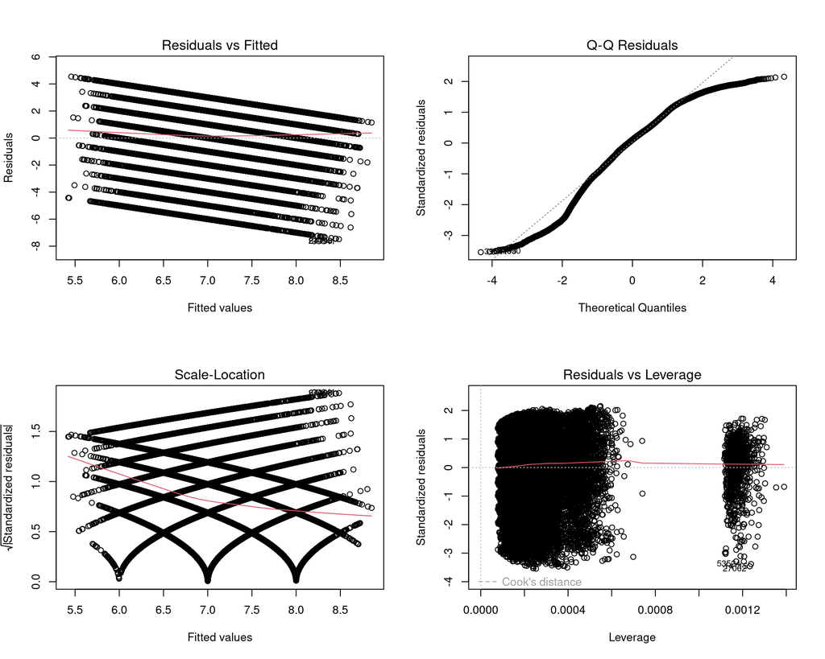

Rysunek 3. Diagnostyka modelu regresji (reszty)

```r
par(mfrow = c(2, 2))
plot(model)
```

```r
par(mfrow = c(1, 1))
```

### 5.2.4 5.2.4. Interpretacja

- **R² = 0.0507** — model wyjaśnia około **5.1%** zmienności zadowolenia z życia.
- **R²_adj = 0.0505** — wartość skorygowana o liczbę predyktorów (uwzględnia karę za złożoność modelu).
- **F(14, 6.4898^{4}) = 247.78, p = <2e-16** — model jako całość jest istotny statystycznie przy α = 0.05.

**Interpretacja kierunków współczynników β** (przy ceteris paribus):

- **`income`** — dodatni β oznacza, że wyższy decyl dochodu wiąże się z wyższym zadowoleniem z życia.
- **`age`** — znak β wskazuje, czy zadowolenie rośnie (β > 0), czy maleje (β < 0) z wiekiem.
- **`trust`** — osoby ufające innym mają (przeciętnie) wyższe `life_sat` o wartość β_trust w porównaniu z nieufającymi.
- **`religion`** — pamiętaj o odwróconej skali (1 = bardzo ważna, 4 = nieważna). Ujemny β oznacza, że spadek religijności wiąże się ze spadkiem zadowolenia (czyli bardziej religijni są bardziej zadowoleni).
- **`education`** — efekty względem grupy referencyjnej (poziom „Brak”). Istotność widoczna w kolumnie p-value.
- **`sex` (Kobieta vs Mężczyzna)** — różnica średnia po kontroli pozostałych predyktorów; poziomem referencyjnym jest „Mężczyzna”.
- **`politics`** — przesunięcie poglądów w prawo (1 → 10) zmienia `life_sat` o β jednostek.

**Istotne predyktory (p < 0.05):** zaznaczone w kolumnie *„p < 0.05”* Tabeli 10.

# 6 PODSUMOWANIE I WNIOSKI

## 6.1 Główne ustalenia

**2. Hipoteza o „kooperatywnym typie osobowości”.** Część III dostarcza empirycznych dowodów na rzecz tej hipotezy:

- **P(A|B) ≠ P(A)** — prawdopodobieństwo deklarowania zaufania jest istotnie wyższe wśród osób odrzucających zachowanie *free-rider* niż w populacji ogólnej.
- Test χ² potwierdza statystyczną zależność obu postaw (p < 0.001).
- Wynik jest spójny z modelami iterowanego dylematu więźnia (Axelrod, 1984) oraz strategii **Tit-for-Tat**: jednostki o nastawieniu kooperatywnym konsekwentnie wybierają strategie zaufania w wielu domenach społecznych, tworząc rozpoznawalny klaster behawioralny.

**3. Zaufanie a zadowolenie z życia.** W modelu regresji liniowej (Część V.2) zaufanie społeczne pozostaje istotnym predyktorem zadowolenia z życia *nawet po kontroli* dochodu, wykształcenia, wieku, płci, religijności i poglądów politycznych. Sugeruje to, że zaufanie ma **niezależny, autonomiczny wkład** w subiektywny dobrostan — nie redukuje się wyłącznie do efektu materialnego ani demograficznego. Stanowi to argument na rzecz koncepcji **kapitału społecznego** (Putnam, 2000) jako samodzielnego komponentu jakości życia.

## 6.2 Ograniczenia badania

- **Charakter proxy:** zmienne WVS o zaufaniu i potępianiu jazdy bez biletu są behawioralnymi *proxy*, a nie pomiarami rzeczywistego zachowania w grach eksperymentalnych. Deklarowana postawa nie zawsze przekłada się na realne wybory.
- **Self-reported data:** odpowiedzi mogą zawierać tendencyjność społeczną (*social desirability bias*) — respondenci skłonni są deklarować większą uczciwość niż wykazują w praktyce.
- **Heterogeniczność krajowa:** różnice kulturowe między ~70 krajami w WVS Wave 7 mogą maskować subtelniejsze efekty na poziomie indywidualnym. Zagregowana analiza nie wyodrębnia efektów krajowych od indywidualnych.
- **Umiarkowane R² modelu regresji:** zadowolenie z życia jest determinowane wieloma czynnikami nieobserwowanymi (osobowość, zdrowie, relacje rodzinne, historia życia), których WVS nie mierzy.
- **Duża próba a istotność statystyczna:** przy N > 30 000 nawet znikome różnice stają się istotne statystycznie. Należy zatem zwracać uwagę na *wielkość efektu* (Cohen’s d, η²), a nie tylko na p-value.
- **Brak danych panelowych:** WVS to dane przekrojowe — nie pozwalają na wnioski przyczynowe. Możemy mówić o *korelacjach*, nie o *przyczynach*.

## 6.3 Możliwe kierunki rozszerzenia

- Modele wielopoziomowe (kraj → respondent) — uwzględnienie zagnieżdżonej struktury danych i odróżnienie efektów indywidualnych od kontekstowych.
- Regresja logistyczna dla `trust` jako zmiennej binarnej — bardziej naturalna niż traktowanie jej jako ciągłej.
- Analiza efektów interakcji (np. płeć × kraj, religia × wykształcenie).
- Porównanie z wcześniejszymi falami WVS w celu zbadania trendów w czasie.
- Wprowadzenie miar wielkości efektu (Cohen’s d, V Craméra) obok testów istotności.

*Raport wygenerowany w R Markdown — 2026-05-24 19:15*